# Sparse Gaussian MRF Mixtures for Anomaly Detection

Koji Makiyama (@hoxo_m)

2018-02-27

## 1 Overview

The **sGMRFmix** package provides an implementation of the algorithm presented by Ide et al. (2016). It is a novel anomaly detection method for multivariate noisy sensor data. It can automatically handle multiple operational modes. And it can also compute variable-wise anomaly scores.

First, we prepare a multivariate training data that contains no anomaly observations. It consists of four parts and repeats two operational modes.

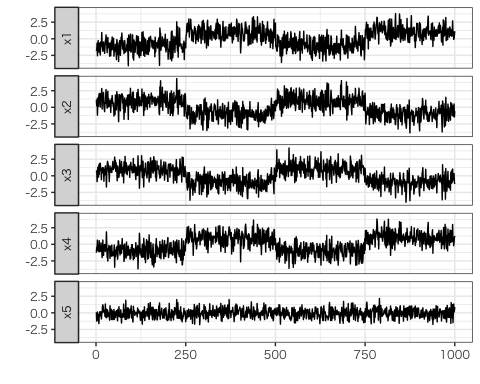

```r
library(sGMRFmix)
set.seed(314)
train_data <- generate_train_data()
plot_multivariate_data(train_data)
```

Second, we prepare a multivariate test data that contains some anomaly values. It consists of 500 normal observations and 500 anomaly observations. The normal part in the test data consists of two operational modes that also have seen in the training data. Note that the variable `x5` has no difference in the normal and anomaly part.

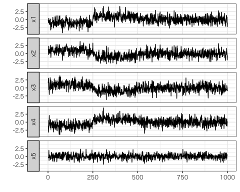

```r
test_data <- generate_test_data()
plot_multivariate_data(test_data)
```

We input the training data to the `sGMRFmix()` function to learn the two operational modes. Then we compute variable-wise anomaly scores for test data using the result.

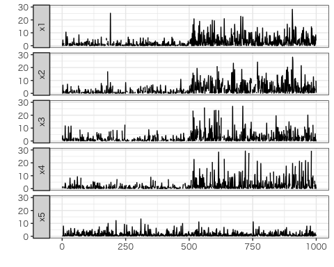

```r
fit <- sGMRFmix(train_data, K = 7, rho = 1.3, verbose = FALSE)
anomaly_score <- compute_anomaly_score(fit, test_data)
plot_multivariate_data(anomaly_score) + ylim(0, 30)
```

You can see that high anomaly scores appear in the latter part of the test data. And you can also see the variable `x5` has no high anomaly scores.

## 2 Installation

You can install the package from GitHub.

```r
install.packages("devtools") # if you have not installed "devtools" package
devtools::install_github("hoxo-m/sGMRFmix")
```

The source code for **sGMRFmix** package is available on GitHub at

https://github.com/hoxo-m/sGMRFmix.

## 3 Details

### 3.1 Basics

The **sGMRFmix** package mainly provides two functions as follows:

- `sGMRFmix` to fit the model and
- `compute_anomaly_score` to compute anomaly scores.

```r
library(sGMRFmix)

fit <- sGMRFmix(train_data, K, rho)
anomaly_score <- compute_anomaly_score(fit, test_data)
```

There are two hyperparameters as below.

- `K` is a max number of mixture components.
- `rho` is a constant that multiplies to the penalty term in the model.

You should set `K` a large enough number because the algorithm identifies major dependency patterns from the data via the sparse mixture model.

You should determine `rho` an optimal value to maximize the performance of anomaly detection.

### 3.2 Data

To fit the model, you must prepare two kinds of data as follows:

- Training data without anomalies to fit the model and
- Labeled test data that contains anomalies to tuning the hyperparameter `rho`.

The package provides functions to generate synthetic data.

```r
set.seed(314)
train_data <- generate_train_data()
head(train_data)
```

```
#>           x1         x2          x3         x4          x5
#> 1 -1.8269027  1.0745443  0.56970302 -1.2568921  0.08997801
#> 2 -1.6120444  0.2252822  0.74793059 -0.4788593 -1.25022520
#> 3 -0.6661666  1.2513592 -0.87397154 -0.3561145 -0.59305259
#> 4 -2.5561030 -1.1858031  0.08327536  0.6284850  0.12603220
#> 5 -1.3413068  0.7235066  1.28744741 -0.9630511 -1.10169444
#> 6 -0.2811875  1.4805043  0.33644955 -0.5148741 -0.20605220
```

```r
test_data <- generate_test_data()
head(test_data)
```

```
#>           x1         x2          x3          x4          x5
#> 1 -0.1534335  1.1129516  1.61478168 -1.15048817 -0.42104579
#> 2 -0.6737145  1.3716102  2.30689870 -1.41350416 -0.26243160
#> 3 -1.0491129 -0.2908006  3.04536973 -3.15425980 -0.46513038
#> 4  0.3412411  2.3378319 -0.56224407  0.51954178  0.05482343
#> 5  0.2378417  1.6324559  1.63852619 -1.11463852  1.87995270
#> 6 -0.3792480  0.3993461 -0.03158052  0.06132161 -1.27252108
```

```r
test_labels <- generate_test_labels()
head(test_labels)
```

```
#>      x1    x2    x3    x4    x5
#> 1 FALSE FALSE FALSE FALSE FALSE
#> 2 FALSE FALSE FALSE FALSE FALSE
#> 3 FALSE FALSE FALSE FALSE FALSE
#> 4 FALSE FALSE FALSE FALSE FALSE
#> 5 FALSE FALSE FALSE FALSE FALSE
#> 6 FALSE FALSE FALSE FALSE FALSE
```

Also, the package provides a function to visualize these data.

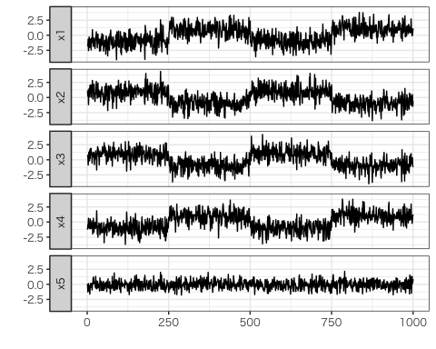

```r
plot_multivariate_data(train_data)
```

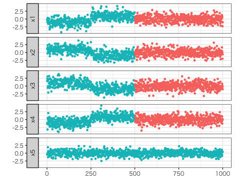

```r
plot_multivariate_data(test_data, label = test_labels)
```

### 3.3 Fitting Model

The package provides the `sGMRFmix()` function to fit the model named *Sparse Gaussian Markov Random Field Mixtures* (Ide et al., 2016). It can automatically handle multiple operational modes. And it can also compute variable-wise anomaly scores.

```r
fit <- sGMRFmix(train_data, K = 7, rho = 1.3, verbose = FALSE)
fit
```

```
#>
#> Call:
#> sGMRFmix(x = train_data, K = 7, rho = 1.3, verbose = FALSE)
#>
#> Data: 1000 x 5
#> Parameters:
#>   K:    7
#>   rho:  1.3
#> Estimated:
#>   Kest: 2
#>   pi:   0.502 0.498
#>   m, A, theta, H, mode
```

As the result of we set `K` to 7 and fit the model, the number of mixtures `K-est` has been sparsely estimated 2. The weights of the mixtures are displayed as `pi`. They are near 0.5. The result contains other estimated parameters such as `m`, `A`, `theta`.

### 3.4 Tuning Hyperparameter `rho`

You can fit the model without labeled data, but you should prepare a labeled test data to tell the model what the anomalies are. To tell it, you have no choice but to tune the hyperparameter `rho`. To avoid overfitting, you can use cross-validation. We measure the performance of the anomaly detection by ROC-AUC.

```r
n_split <- 5
split_block <- sample(n_split, size = nrow(test_data), replace = TRUE)
split_test_data <- split(test_data, split_block)
split_test_labels <- split(test_labels, split_block)

rho_candidates <- 10^seq(-1, 1, length.out = 10)

library(ModelMetrics)

df <- data.frame()
for (rho in rho_candidates) {
  fit <- sGMRFmix(train_data, K = 7, rho = rho, verbose = FALSE)
  auc <- double(n_split)
  for (i in seq_len(n_split)) {
    anomaly_score <- compute_anomaly_score(fit, split_test_data[[i]])
    auc[i] <- auc(unlist(split_test_labels[[i]]), unlist(anomaly_score))
  }
  df <- rbind(df, data.frame(rho = rho, auc = auc))
}
```

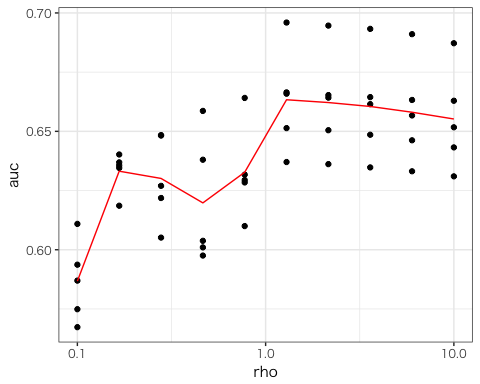

```r
library(ggplot2)
ggplot(df, aes(rho, auc)) + geom_point() +
  stat_summary(fun.y = mean, geom = "line", color = "red") + scale_x_log10()
```

```r
library(dplyr)
df %>% group_by(rho) %>% summarise(mean_auc = mean(auc)) %>%
  mutate(max = ifelse(max(mean_auc) == mean_auc, "***", "."))
```

```
#> # A tibble: 10 x 3
#>       rho mean_auc max
#>     <dbl>    <dbl> <chr>
#>  1  0.100    0.587 .
#>  2  0.167    0.633 .
#>  3  0.278    0.630 .
#>  4  0.464    0.620 .
#>  5  0.774    0.633 .
#>  6  1.29     0.663 ***
#>  7  2.15     0.662 .
#>  8  3.59     0.661 .
#>  9  5.99     0.658 .
#> 10 10.0      0.655 .
```

Optimal `rho` value that has the best performance to detect anomalies we think is 1.29.

### 3.5 Anomaly Detection

We have obtained optimal hyperparameter `rho.` Next, let us investigate optimal threshold value for anomaly scores. We measure the performance of the anomaly detection by F-measure.

```r
optimal_rho <- 1.29
fit <- sGMRFmix(train_data, K = 7, rho = optimal_rho, verbose = FALSE)

threshold_candidates <- 10^seq(-1, 1, length.out = 100)
df <- data.frame()
for (i in seq_len(n_split)) {
  anomaly_score <- compute_anomaly_score(fit, split_test_data[[i]])
  f_measure <- double(length(threshold_candidates))
  for (j in seq_along(threshold_candidates)) {
    f1 <- f1Score(unlist(split_test_labels[[i]]), unlist(anomaly_score),
                  cutoff = threshold_candidates[j])
    f_measure[j] <- f1
  }
  df <- rbind(df, data.frame(cutoff = threshold_candidates, f_measure = f_measure))
}
```

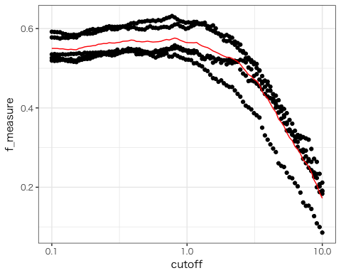

```r
ggplot(df, aes(cutoff, f_measure)) + geom_point() +
  stat_summary(fun.y = mean, geom = "line", color = "red") + scale_x_log10()
```

```r
df %>% group_by(cutoff) %>%
  summarise(mean_f_measure = mean(f_measure)) %>%
  filter(mean_f_measure == max(mean_f_measure))
```

```
#> # A tibble: 1 x 2
#>   cutoff mean_f_measure
#>    <dbl>          <dbl>
#> 1  0.811          0.576
```

We found optimal threshold is 0.811.

We can use the value for anomaly detection.

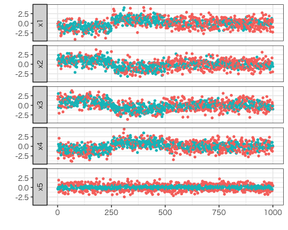

```r
anomaly_scores <- compute_anomaly_score(fit, test_data)
is_anomaly <- anomaly_scores > 0.811
plot_multivariate_data(test_data, label = is_anomaly)
```

### 3.6 Moving Average of Anomaly Scores

In the above example, you might think the F-measure is low. There is another way if you are interested in whether anomalies occur densely rather than individual one.

You can calculate moving average (or called rolling mean) for the anomaly scores by indicating window size.

```r
window_size <- 20

df <- data.frame()
for (i in seq_len(n_split)) {
  anomaly_score <- compute_anomaly_score(fit, split_test_data[[i]], window_size)
  f_measure <- double(length(threshold_candidates))
  for (j in seq_along(threshold_candidates)) {
    f1 <- f1Score(unlist(split_test_labels[[i]]), unlist(anomaly_score),
                  cutoff = threshold_candidates[j])
    f_measure[j] <- f1
  }
  df <- rbind(df, data.frame(cutoff = threshold_candidates, f_measure = f_measure))
}
```

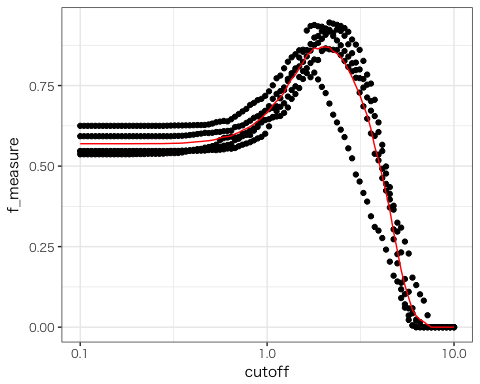

```r
ggplot(df, aes(cutoff, f_measure)) + geom_point() +
  stat_summary(fun.y = mean, geom = "line", color = "red") + scale_x_log10()
```

```r
df %>% group_by(cutoff) %>%
  summarise(mean_f_measure = mean(f_measure)) %>%
  filter(mean_f_measure == max(mean_f_measure))
```

```
#> # A tibble: 1 x 2
#>   cutoff mean_f_measure
#>    <dbl>          <dbl>
#> 1   1.96          0.870
```

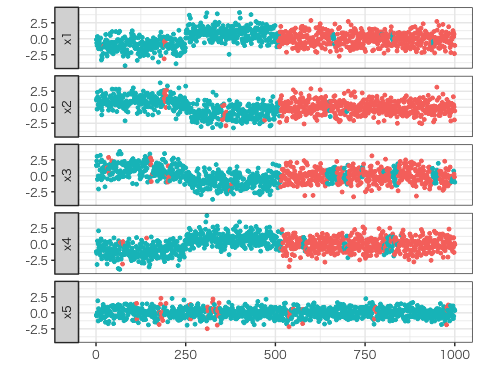

```r
anomaly_scores <- compute_anomaly_score(fit, test_data, window_size)
is_anomaly <- anomaly_scores > 1.96
plot_multivariate_data(test_data, label = is_anomaly)
```

You can see that we obtained an anomaly detector with high performance.

### 3.7 Structures of Operational Modes

In the above, the model has identified that synthetic data consists of two operational modes. We can see it as follows:

```r
fit$Kest
```

```
#> [1] 2
```

We can also see the weight indicating how often these modes appear.

```r
fit$pi
```

```
#> [1] 0.5020797 0.4979203
```

Furthermore, we can also see the structure of each mode. `fit$mode` is the assigned mode to each observation in the training data.

```r
head(fit$mode, 10)
```

```
#>  [1] 2 1 1 1 1 1 1 2 1 1
```

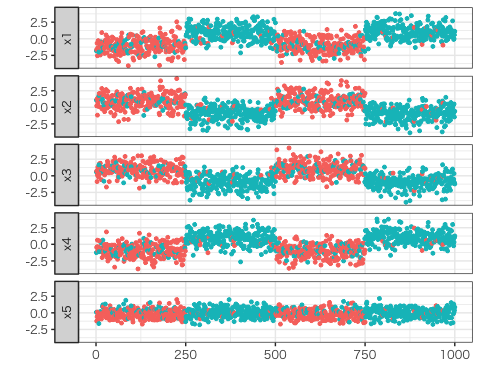

```r
plot_multivariate_data(train_data, label = fit$mode)
```

Using this, we can show the correlation structures for each mode.

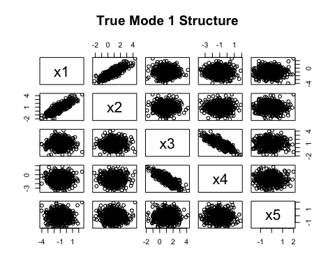

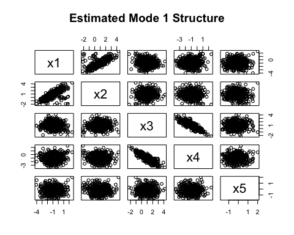

```r
inds_mode1 <- c(1:250, 501:750)
true_mode1_values <- train_data[inds_mode1, ]
estimated_mode1_values <- train_data[fit$mode == 1, ]

pairs(true_mode1_values, main="True Mode 1 Structure")
pairs(estimated_mode1_values, main="Estimated Mode 1 Structure")
```

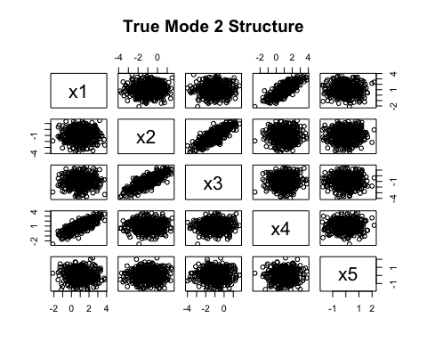

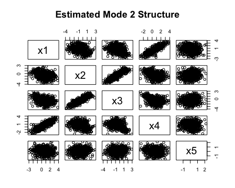

```r
inds_mode2 <- c(251:500, 751:1000)
true_mode2_values <- train_data[inds_mode2, ]
estimated_mode2_values <- train_data[fit$mode == 2, ]

pairs(true_mode2_values, main="True Mode 2 Structure")
pairs(estimated_mode2_values, main="Estimated Mode 2 Structure")
```

In reality, true structures are unknown. We should check estimated structures and consider whether it is reasonable.

You can also see the structure of the anomaly state. To compare it with the normal operating modes will be helpful to investigate what caused the anomalies.

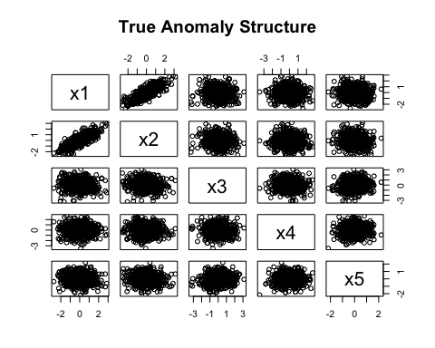

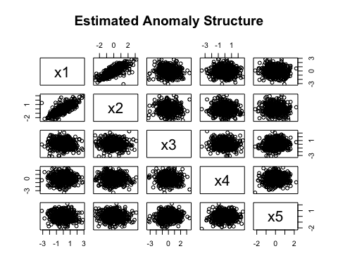

```r
true_anomlay <- test_data[501:1000, ]
estimated_anomaly <- test_data[is_anomaly, ]

pairs(true_anomlay, main="True Anomaly Structure")
pairs(estimated_anomaly, main="Estimated Anomaly Structure")
```

## Reference

- T. Ide, A .Khandelwal, J .Kalagnanam, **Sparse Gaussian Markov Random Field Mixtures for Anomaly Detection**, IEEE 16th International Conference on Data Mining (ICDM), 2016, pp 955–960